# Week 9 Tutorial

ECON90033 - 2023 Semester 2

Josh Copeland

Completed on 16 October 2023

## Exercise 1

An important application of GARCH models examines how volatility is transmitted through different regions of the world during the course of a global financial trading day. Shocks to major markets can have delayed effects because they operate in different time zones.

You can model this spillover by splitting each day into three trading zones: Japan, Europe and the US.

## Exercise 1

### a) Compute the percentage log returns on the DAX, NKX and SPX indices. Plot the three return series, calculate the usual descriptive statistics for each of them and briefly discuss the results regarding skewness, kurtosis and normality.

All three plots exhibit changing volatility with more or less coinciding periods of high and low volatility.

The reported skewness statistics are negative, implying they’re all left skewed. However, DAX’s value is insignificant at the 5% level.

All kurtosis statistics are above 3 and and kurt.2se value > 1, implying they all have fat-tail distributions relative to the normal distribution: they are leptokurtic.

Therefore, its not surprising the SW tests have zero p-values (last row), so they reject normality at any reasonable significance level.

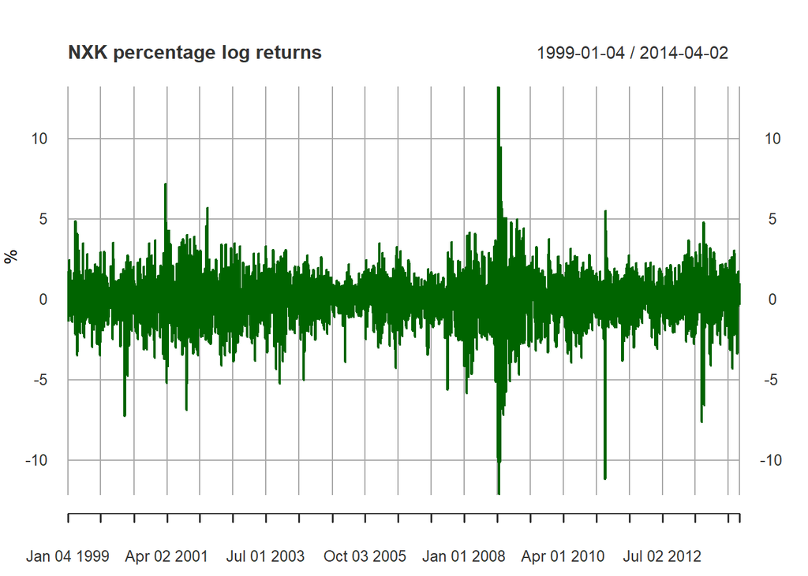

```r
e1 <- read_excel("C:/Users/joshc/Documents/2023S2/ECON90033/Tutorials/Week 9/t9e1.xlsx")

Date <- e1 %>%
  pull(Date)

# library(xts)

NKX <- e1 %>%
  pull(NKX) %>%
  xts(order.by = as.Date(Date))

NKX_r <- (log(NKX) - lag(log(NKX),1))*100

DAX <- e1 %>%
  pull(DAX) %>%
  xts(order.by = as.Date(Date))

DAX_r <- (log(DAX) - lag(log(DAX),1))*100

SPX <- e1 %>%
  pull(SPX) %>%
  xts(order.by = as.Date(Date))

SPX_r <- (log(SPX) - lag(log(SPX),1))*100

plot.xts(NKX_r, xlab = "Date", ylab = "%", main = "NXK percentage log returns", col = "darkgreen")
```

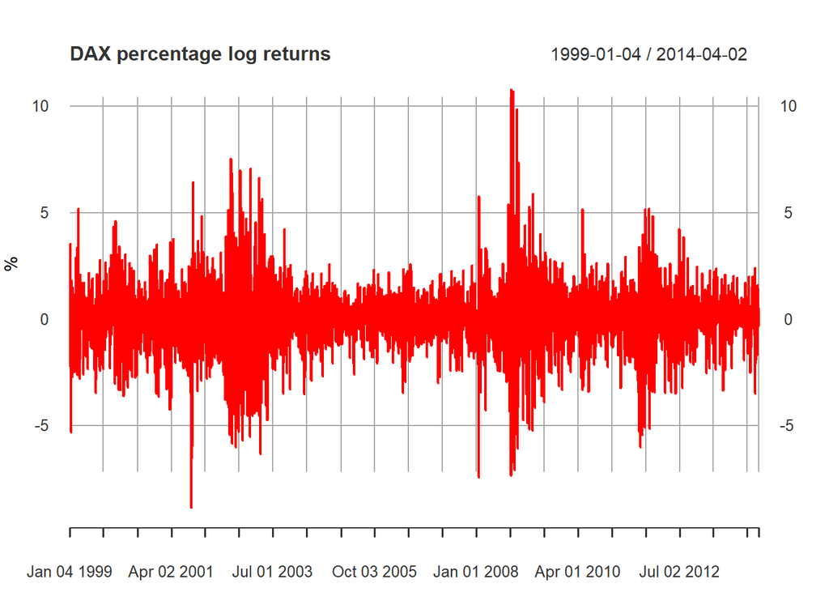

```r
plot.xts(DAX_r, xlab = "Date", ylab = "%", main = "DAX percentage log returns", col = "red")
```

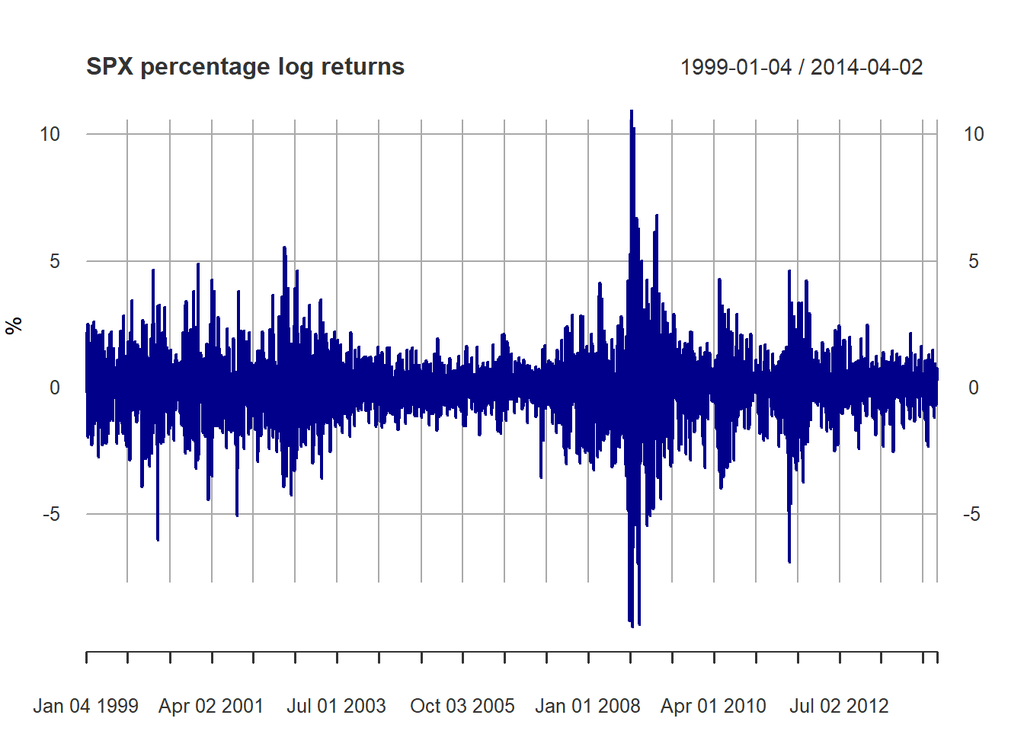

```r
plot.xts(SPX_r, xlab = "Date", ylab = "%", main = "SPX percentage log returns", col = "darkblue")
```

```r
options(scipen = 1000)
round(stat.desc(cbind(NKX_r, DAX_r, SPX_r), basic = FALSE, norm = TRUE), 4)
```

```
##                 NKX_r    DAX_r    SPX_r
## median         0.0000   0.0482   0.0195
## mean           0.0027   0.0152   0.0109
## SE.mean        0.0240   0.0244   0.0202
## CI.mean.0.95   0.0470   0.0479   0.0396
## var            2.2875   2.3773   1.6215
## std.dev        1.5125   1.5418   1.2734
## coef.var     556.8179 101.2670 117.3403
## skewness      -0.4184  -0.0194  -0.1713
## skew.2SE      -5.3874  -0.2498  -2.2059
## kurtosis       6.6227   4.4092   7.8871
## kurt.2SE      42.6530  28.3975  50.7964
## normtest.W     0.9421   0.9462   0.9161
## normtest.p     0.0000   0.0000   0.0000
```

### b) Computer the deviations of returns from their respective sample mean, which are estimates of epsilon. Find the best fitting ARMA model for each error series using auto.arima.

This exercise tells us that:

- NXK errors are best modelled as white noise
- DAX errors are best modelled as ARMA(3,1)
- SPX errors are best modelled as ARMA(1,1)

```r
NKX_e = NKX_r - mean(NKX_r, na.rm = TRUE)
DAX_e = DAX_r - mean(DAX_r, na.rm = TRUE)
SPX_e = SPX_r - mean(SPX_r, na.rm = TRUE)

auto.arima(NKX_e)
```

```
## Series: NKX_e
## ARIMA(0,0,0) with zero mean
##
## sigma^2 = 2.287:  log likelihood = -7288.04
## AIC=14578.09   AICc=14578.09   BIC=14584.38
```

```r
auto.arima(DAX_e)
```

```
## Series: DAX_e
## ARIMA(3,0,1) with zero mean
##
## Coefficients:
##           ar1      ar2      ar3     ma1
##       -0.6014  -0.0215  -0.0461  0.5873
## s.e.   0.1710   0.0187   0.0163  0.1707
##
## sigma^2 = 2.373:  log likelihood = -7359.21
## AIC=14728.43   AICc=14728.44   BIC=14759.87
```

```r
auto.arima(SPX_e)
```

```
## Series: SPX_e
## ARIMA(1,0,1) with zero mean
##
## Coefficients:
##          ar1      ma1
##       0.5186  -0.6007
## s.e.  0.1368   0.1284
##
## sigma^2 = 1.607:  log likelihood = -6585.53
## AIC=13177.05   AICc=13177.06   BIC=13195.92
```

### c) the NKX, DAX and SPX indices are from teh Japanese, Europrean and US markets respectively. Given the discussion about about heatwaves, meteor showers and the suggest mean equations from part (b), estiamte the given GARCH(1,1) model for NKX.

```r
#Calculate squared deviations

NKX_e2 <- NKX_e^2
DAX_e2 <- DAX_e^2
SPX_e2 <- SPX_e^2

library(rugarch)
options(scipen = 0)

n = length(NKX)

spec_NKX <- ugarchspec(mean.model = list(armaOrder = c(0,0), include.mean = FALSE),
                       variance.model = list(model = "sGARCH",
                                             garchOrder = c(1,1),
                                             external.regressors = cbind(lag(DAX_e2)[3:n,1],
                                                                         lag(SPX_e2)[3:n,1])),
                       distribution.model = "norm")

fit_NKX <- ugarchfit(spec = spec_NKX, data = NKX_e[3:n,1])
fit_NKX
```

```
##
## *---------------------------------*
## *          GARCH Model Fit        *
## *---------------------------------*
##
## Conditional Variance Dynamics
## -----------------------------------
## GARCH Model  : sGARCH(1,1)
## Mean Model   : ARFIMA(0,0,0)
## Distribution : norm
##
## Optimal Parameters
## ------------------------------------
##         Estimate  Std. Error  t value Pr(>|t|)
## omega   0.072666    0.021481   3.3828 0.000718
## alpha1  0.091223    0.010587   8.6168 0.000000
## beta1   0.813930    0.029463  27.6259 0.000000
## vxreg1  0.010082    0.007190   1.4022 0.160843
## vxreg2  0.077398    0.017098   4.5268 0.000006
##
## Robust Standard Errors:
##         Estimate  Std. Error  t value Pr(>|t|)
## omega   0.072666    0.050525  1.43822 0.150372
## alpha1  0.091223    0.017963  5.07835 0.000000
## beta1   0.813930    0.075030 10.84812 0.000000
## vxreg1  0.010082    0.014645  0.68843 0.491181
## vxreg2  0.077398    0.038684  2.00080 0.045414
##
## LogLikelihood : -6776.272
##
## Information Criteria
## ------------------------------------
##
## Akaike       3.4111
## Bayes        3.4190
## Shibata      3.4111
## Hannan-Quinn 3.4139
##
## Weighted Ljung-Box Test on Standardized Residuals
## ------------------------------------
```

[output cut: 40 more lines]

```
## Negative Sign Bias   1.568 1.170e-01
## Positive Sign Bias   3.269 1.090e-03 ***
## Joint Effect        26.865 6.284e-06 ***
##
##
## Adjusted Pearson Goodness-of-Fit Test:
## ------------------------------------
##   group statistic p-value(g-1)
## 1    20     406.3    2.100e-74
## 2    30     549.7    1.661e-97
## 3    40     665.3   5.875e-115
## 4    50     805.9   1.386e-137
##
##
## Elapsed time : 0.4531879
```

### d) Based on the suggested mean equation in part (b), estimate a GARCH(1,1) model for the DAX index.

```r
spec_DAX <- ugarchspec(mean.model = list(armaOrder = c(3,1),
                                         include.mean = FALSE),
                       variance.model = list(model = "sGARCH",
                                             garchOrder = c(1,1),
                                             external.regressors = cbind(NKX_e2[3:n,1],
                                                                         lag(SPX_e2)[3:n,1])),
                       distribution.model = "norm")

fit_DAX = ugarchfit(spec = spec_DAX, data = DAX_e[3:n,1])
fit_DAX
```

```
##
## *---------------------------------*
## *          GARCH Model Fit        *
## *---------------------------------*
##
## Conditional Variance Dynamics
## -----------------------------------
## GARCH Model  : sGARCH(1,1)
## Mean Model   : ARFIMA(3,0,1)
## Distribution : norm
##
## Optimal Parameters
## ------------------------------------
##         Estimate  Std. Error  t value Pr(>|t|)
## ar1    -0.501573    0.324438 -1.54598 0.122110
## ar2    -0.002987    0.019475 -0.15338 0.878095
## ar3    -0.023946    0.017778 -1.34694 0.178001
## ma1     0.487838    0.324585  1.50296 0.132850
## omega   0.016667    0.004901  3.40044 0.000673
## alpha1  0.070323    0.007869  8.93729 0.000000
## beta1   0.895908    0.010027 89.35375 0.000000
## vxreg1  0.007666    0.002977  2.57479 0.010030
## vxreg2  0.027765    0.007370  3.76748 0.000165
##
## Robust Standard Errors:
##         Estimate  Std. Error  t value Pr(>|t|)
## ar1    -0.501573    0.270316  -1.8555 0.063524
## ar2    -0.002987    0.019334  -0.1545 0.877215
## ar3    -0.023946    0.017011  -1.4077 0.159227
## ma1     0.487838    0.269539   1.8099 0.070312
## omega   0.016667    0.005758   2.8946 0.003796
## alpha1  0.070323    0.009826   7.1570 0.000000
## beta1   0.895908    0.014126  63.4209 0.000000
## vxreg1  0.007666    0.003424   2.2386 0.025182
## vxreg2  0.027765    0.010443   2.6588 0.007842
##
## LogLikelihood : -6635.564
##
## Information Criteria
## ------------------------------------
```

[output cut: 52 more lines]

```
## Negative Sign Bias  0.5253 5.994e-01
## Positive Sign Bias  3.4713 5.234e-04 ***
## Joint Effect       40.9858 6.585e-09 ***
##
##
## Adjusted Pearson Goodness-of-Fit Test:
## ------------------------------------
##   group statistic p-value(g-1)
## 1    20     141.7    8.762e-21
## 2    30     177.0    3.609e-23
## 3    40     192.5    3.429e-22
## 4    50     207.7    1.984e-21
##
##
## Elapsed time : 0.635699
```

### e) Based on the suggested mean equation in part (b), estimate a GARCH(1,1) model for the SPX index.

```r
spec_SPX <- ugarchspec(mean.model = list(armaOrder = c(1,1),
                                         include.mean = FALSE),

                       variance.model = list(model = "sGARCH",
                                             garchOrder = c(1,1),
                                             external.regressors = cbind(NKX_e2[3:n,1],
                                                                         DAX_e2[3:n,1])),

                       distribution.model = "norm")

fit_SPX <- ugarchfit(spec = spec_SPX, data = SPX_e[3:n,1])
fit_SPX
```

```
##
## *---------------------------------*
## *          GARCH Model Fit        *
## *---------------------------------*
##
## Conditional Variance Dynamics
## -----------------------------------
## GARCH Model  : sGARCH(1,1)
## Mean Model   : ARFIMA(1,0,1)
## Distribution : norm
##
## Optimal Parameters
## ------------------------------------
##         Estimate  Std. Error    t value Pr(>|t|)
## ar1     0.721776    0.097090   7.434086 0.000000
## ma1    -0.769265    0.089292  -8.615191 0.000000
## omega   0.013182    0.002793   4.719199 0.000002
## alpha1  0.075023    0.007680   9.769236 0.000000
## beta1   0.915485    0.008259 110.846077 0.000000
## vxreg1  0.000000    0.001097   0.000009 0.999993
## vxreg2  0.000000    0.001347   0.000008 0.999993
##
## Robust Standard Errors:
##         Estimate  Std. Error    t value Pr(>|t|)
## ar1     0.721776    0.081913   8.811456 0.000000
## ma1    -0.769265    0.076743 -10.023912 0.000000
## omega   0.013182    0.004378   3.010967 0.002604
## alpha1  0.075023    0.012595   5.956691 0.000000
## beta1   0.915485    0.012311  74.363336 0.000000
## vxreg1  0.000000    0.001506   0.000007 0.999995
## vxreg2  0.000000    0.002379   0.000005 0.999996
##
## LogLikelihood : -5744.889
##
## Information Criteria
## ------------------------------------
##
## Akaike       2.8933
## Bayes        2.9044
## Shibata      2.8933
```

[output cut: 46 more lines]

```
## Negative Sign Bias   1.657 9.758e-02   *
## Positive Sign Bias   3.126 1.787e-03 ***
## Joint Effect        40.974 6.624e-09 ***
##
##
## Adjusted Pearson Goodness-of-Fit Test:
## ------------------------------------
##   group statistic p-value(g-1)
## 1    20     191.9    1.408e-30
## 2    30     214.7    3.014e-30
## 3    40     228.5    1.193e-28
## 4    50     253.6    2.244e-29
##
##
## Elapsed time : 0.2541029
```

### f) summarise the parameter estimates and thier significance in a table and briefly discuss them in terms of heatwaves and meteor showers in volatility patterns between Japan, Europe and the US.

The table below shows the results from these three models (*: 10%, **:5%,*** :1%)

[figure not shown]

```r
knitr::include_graphics("e1f.png")
```